# Bivariate analysis

```python
import seaborn as sns
```

In univariate analysis we only looked at 1 variable (= 1 column) at a time. In bivariate analysis we will now look at the relation between two variables (= 2 columns).

The type of analysis we can do will once again depend on the types of data of these 2 variables. We look look at:

- Numerical VS Numerical.
- Nummerical VS Categorical
- Categorical VS Categorical

## Numerical VS Numerical

Examples:

- Body length VS Shoe size
- Age VS Seconds it takes to run 1 kilometre
- Country Unemployment rate VS Country Happiness Rating
- Customer Revenue VS Customer Lifetime
- Game Wishlists VS Game Purchases
- Student grades VS Student attendance
- ...

```python
import pandas as pd
import seaborn as sns
```

```python
iris = sns.load_dataset("iris")
```

```python
iris.head()
```

|  | sepal_length | sepal_width | petal_length | petal_width | species |
| --- | --- | --- | --- | --- | --- |
| 0 | 5.1 | 3.5 | 1.4 | 0.2 | setosa |
| 1 | 4.9 | 3.0 | 1.4 | 0.2 | setosa |
| 2 | 4.7 | 3.2 | 1.3 | 0.2 | setosa |
| 3 | 4.6 | 3.1 | 1.5 | 0.2 | setosa |
| 4 | 5.0 | 3.6 | 1.4 | 0.2 | setosa |

[figure not shown]

Let's look at the relation between the sepal length and petal length. (Dutch: Kelkblad en bloemblad)

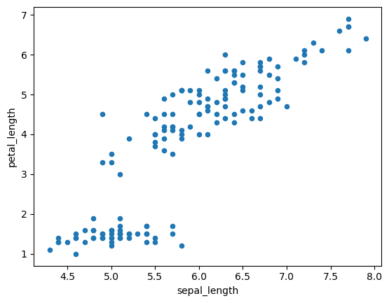

```python
iris.plot(kind='scatter', x='sepal_length', y='petal_length')
```

A useful statistic for calculating the linear relation between two variable is the **Pearson correlation**.  
The Pearson correlation measures the linear relation between two numerical variables. The result is a number between -1 and 1 where

- -1 indicates a perfect negative linear relation
- 0 indicates that there is no linear relation
- 1 indicates a perfect positive linear relation

[figure not shown]

```python
iris[['sepal_length','petal_length']].corr()
```

|  | sepal_length | petal_length |
| --- | --- | --- |
| sepal_length | 1.000000 | 0.871754 |
| petal_length | 0.871754 | 1.000000 |

```python
iris.corr()
```

|  | sepal_length | sepal_width | petal_length | petal_width |
| --- | --- | --- | --- | --- |
| sepal_length | 1.000000 | -0.117570 | 0.871754 | 0.817941 |
| sepal_width | -0.117570 | 1.000000 | -0.428440 | -0.366126 |
| petal_length | 0.871754 | -0.428440 | 1.000000 | 0.962865 |
| petal_width | 0.817941 | -0.366126 | 0.962865 | 1.000000 |

```python
irisCorrelations = iris.corr()
irisCorrelations.style.background_gradient(cmap='coolwarm', axis=None).format(precision=2)
```

|  | sepal_length | sepal_width | petal_length | petal_width |
| --- | --- | --- | --- | --- |
| sepal_length | 1.00 | -0.12 | 0.87 | 0.82 |
| sepal_width | -0.12 | 1.00 | -0.43 | -0.37 |
| petal_length | 0.87 | -0.43 | 1.00 | 0.96 |
| petal_width | 0.82 | -0.37 | 0.96 | 1.00 |

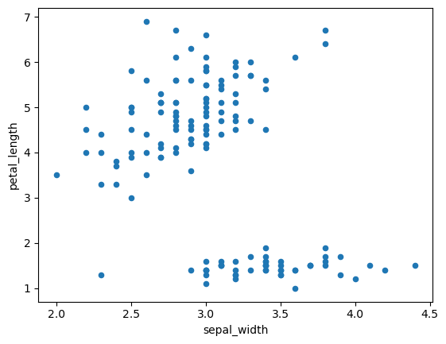

```python
iris.plot(kind='scatter', x='sepal_width', y='petal_length')
```

```python
import numpy as np
```

```python
exampleData = pd.Series(range(100)) + 1
exampleDataNegative = -exampleData
exampleDataDouble = exampleData * 2
exampleDataSquared = exampleData ** 2
exampleDataRoot = exampleData ** 0.5

exampleDataExponential = 2 ** exampleData
exampleDataLog = np.log2(exampleData)

exampleDataWithSmallNoise = exampleData + np.random.randint(low=0, high=10, size=len(exampleData))
exampleDataWithMediumNoise = exampleData + np.random.randint(low=0, high=100, size=len(exampleData))
exampleDataWithHeavyNoise = exampleData + np.random.randint(low=0, high=1000, size=len(exampleData))

exampleDataFrame = pd.DataFrame({'original':exampleData, 'negative':exampleDataNegative, 'double':exampleDataDouble, 'squared':exampleDataSquared, 'root': exampleDataRoot, 'exp':exampleDataExponential, 'log':exampleDataLog, 'noiseSmall': exampleDataWithSmallNoise, 'noiseMedium': exampleDataWithMediumNoise, 'noiseHeavy':exampleDataWithHeavyNoise })
```

```python
exampleDataFrame.head()
```

|  | original | negative | double | squared | root | exp | log | noiseSmall | noiseMedium | noiseHeavy |
| --- | --- | --- | --- | --- | --- | --- | --- | --- | --- | --- |
| 0 | 1 | -1 | 2 | 1 | 1.000000 | 2 | 0.000000 | 3 | 56 | 623 |
| 1 | 2 | -2 | 4 | 4 | 1.414214 | 4 | 1.000000 | 2 | 32 | 684 |
| 2 | 3 | -3 | 6 | 9 | 1.732051 | 8 | 1.584963 | 6 | 16 | 892 |
| 3 | 4 | -4 | 8 | 16 | 2.000000 | 16 | 2.000000 | 12 | 36 | 96 |
| 4 | 5 | -5 | 10 | 25 | 2.236068 | 32 | 2.321928 | 7 | 56 | 531 |

```python
exampleDataCorrelations = exampleDataFrame.corr()
exampleDataCorrelations.style.background_gradient(cmap='coolwarm', axis=None).set_precision(2)
```

|  | original | negative | double | squared | root | exp | log | noiseSmall | noiseMedium | noiseHeavy |
| --- | --- | --- | --- | --- | --- | --- | --- | --- | --- | --- |
| original | 1.00 | -1.00 | 1.00 | 0.97 | 0.98 | -0.01 | 0.90 | 1.00 | 0.67 | 0.08 |
| negative | -1.00 | 1.00 | -1.00 | -0.97 | -0.98 | 0.01 | -0.90 | -1.00 | -0.67 | -0.08 |
| double | 1.00 | -1.00 | 1.00 | 0.97 | 0.98 | -0.01 | 0.90 | 1.00 | 0.67 | 0.08 |
| squared | 0.97 | -0.97 | 0.97 | 1.00 | 0.91 | -0.01 | 0.78 | 0.96 | 0.65 | 0.08 |
| root | 0.98 | -0.98 | 0.98 | 0.91 | 1.00 | -0.00 | 0.96 | 0.98 | 0.66 | 0.07 |
| exp | -0.01 | 0.01 | -0.01 | -0.01 | -0.00 | 1.00 | -0.00 | 0.00 | 0.01 | -0.14 |
| log | 0.90 | -0.90 | 0.90 | 0.78 | 0.96 | -0.00 | 1.00 | 0.90 | 0.61 | 0.05 |
| noiseSmall | 1.00 | -1.00 | 1.00 | 0.96 | 0.98 | 0.00 | 0.90 | 1.00 | 0.66 | 0.08 |
| noiseMedium | 0.67 | -0.67 | 0.67 | 0.65 | 0.66 | 0.01 | 0.61 | 0.66 | 1.00 | 0.00 |
| noiseHeavy | 0.08 | -0.08 | 0.08 | 0.08 | 0.07 | -0.14 | 0.05 | 0.08 | 0.00 | 1.00 |

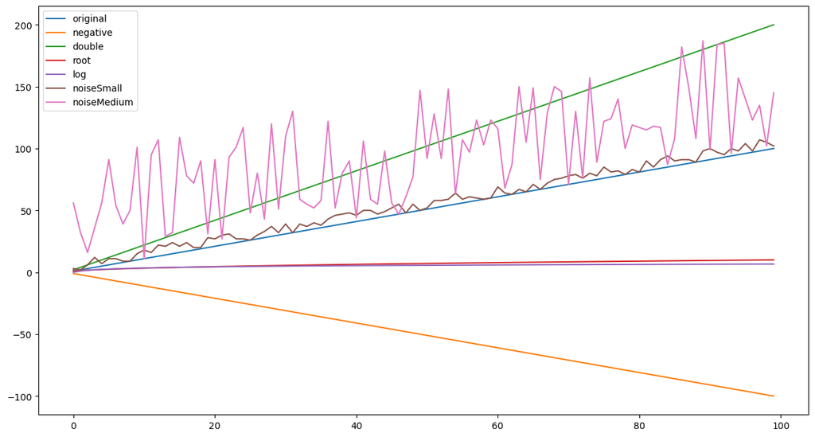

```python
# Excluding a couple of columns because their values are too high to show in the same plot
exampleDataFrame.drop(['exp', 'squared' , 'noiseHeavy'], axis=1).plot(figsize=(15,8))
```

### Portfolio assignment 9

25 min: Perform a bivariate analysis on the columns with numerical data in the penguins dataset.

- Use corr() on the DataFrame to calculate all the correlations. Use the code example above to show the correlation table with colors.
- Look at the corrrelations. Do they match your expectations?
- Show a scatter plot for
  - The strongest positive correlation
  - The strongest negative correlation
  - The weakest correlation

```python
penguins = sns.load_dataset("penguins")
```

```python
penguins.head()
```

|  | species | island | bill_length_mm | bill_depth_mm | flipper_length_mm | body_mass_g | sex |
| --- | --- | --- | --- | --- | --- | --- | --- |
| 0 | Adelie | Torgersen | 39.1 | 18.7 | 181.0 | 3750.0 | Male |
| 1 | Adelie | Torgersen | 39.5 | 17.4 | 186.0 | 3800.0 | Female |
| 2 | Adelie | Torgersen | 40.3 | 18.0 | 195.0 | 3250.0 | Female |
| 3 | Adelie | Torgersen | NaN | NaN | NaN | NaN | NaN |
| 4 | Adelie | Torgersen | 36.7 | 19.3 | 193.0 | 3450.0 | Female |

# Penguins corrolation

```python
penguinsDataCorrelations = penguins.corr()
penguinsDataCorrelations.style.background_gradient(cmap='coolwarm', axis=None).set_precision(2)
```

|  | bill_length_mm | bill_depth_mm | flipper_length_mm | body_mass_g |
| --- | --- | --- | --- | --- |
| bill_length_mm | 1.00 | -0.24 | 0.66 | 0.60 |
| bill_depth_mm | -0.24 | 1.00 | -0.58 | -0.47 |
| flipper_length_mm | 0.66 | -0.58 | 1.00 | 0.87 |
| body_mass_g | 0.60 | -0.47 | 0.87 | 1.00 |

In deze tabel is te zien dat er een sterke positieve corrolatie tussen de body_mass & flipper length. Op zich wel logisch dat wanneer een penguin groter is, zijn flippers langer zijn dan wanneer een penguin kleiner is. Verder is geen sterke corrolatie tussen de bill(beak) van een penguin met de body_mass.

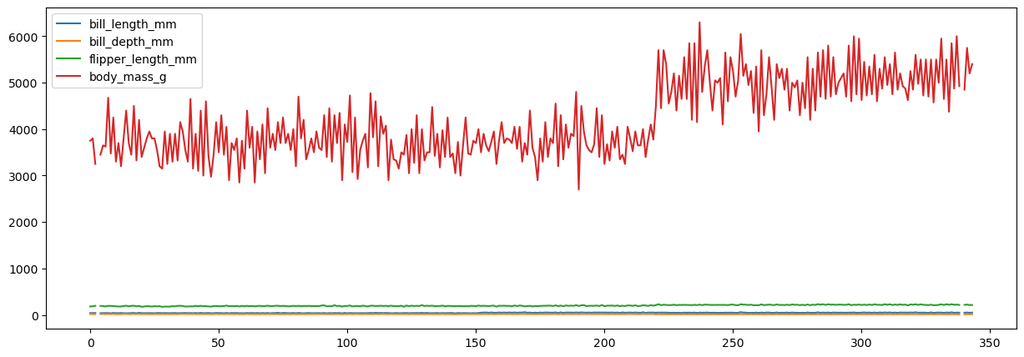

```python
# Excluding a couple of columns because their values are too high to show in the same plot
penguins.plot(figsize=(15,5))
```

# Strongest positive corrolation (0.87)

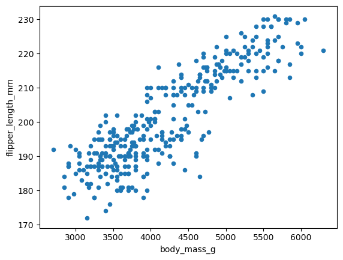

```python
penguins.plot(kind='scatter', x='body_mass_g', y='flipper_length_mm')
```

# The strongest negative correlation (-0,58)

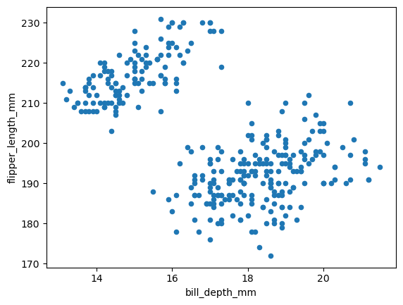

```python
penguins.plot(kind='scatter', x='bill_depth_mm', y='flipper_length_mm')
```

# Weakest Corrolation (-0,24)

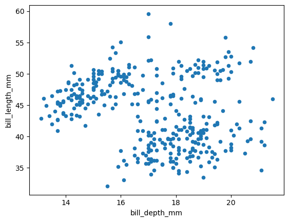

```python
penguins.plot(kind='scatter', x='bill_depth_mm', y='bill_length_mm')
```

[figure not shown]

### Portfolio assignment 10

15 min: Perform a bivariate analysis (Pearson correlation and scatter plot) on at least 1 combination of 2 columns with numeric data in the dataset that you chose in portfolio assignment 4. Does the correlation and scatter plot match your expectations? Add your answer to your notebook. Commit the Notebook to your portfolio when you're finished.

[figure not shown]

## Numerical VS Categorical

Examples:

- Monthly earnings VS Highest obtained degree
- Body length VS Country of origin
- Happiness rating VS Country of origin
- Sales VS Account Manager.
- Revenue VS Product Category
- Revenue VS Game genre
- Retention VS Software version
- ...

In univariate analysis for numerical data we've looked at confidence intervals. We can use these to check if there are any signicant differences between categories.

You and I are are going to roll a 6-sided die. The numerical variable is the value we roll and the categorical variable is who rolled it. We know that in reality the average value of a 6-sided die is 3.5 (=(1+2+3+4+5+6)/6). We know that there is no skill involved, so who rolls the die should have no impact on the result. We each roll the die 3 times.

[figure not shown]

```python
diceRolls = pd.DataFrame(data= {'Person': ['you', 'you', 'you', 'me','me','me'], 'Rolls': [6,3,6,2,4,2]})
diceRolls
```

|  | Person | Rolls |
| --- | --- | --- |
| 0 | you | 6 |
| 1 | you | 3 |
| 2 | you | 6 |
| 3 | me | 2 |
| 4 | me | 4 |
| 5 | me | 2 |

```python
diceRolls.groupby(by="Person").mean()
```

| Person | Rolls |
| --- | --- |
| me | 2.666667 |
| you | 5.000000 |

Looks like you rolled an average value of 5 and I rolled an average value of ~2.7. Does this mean you are better at rolling dice than me?

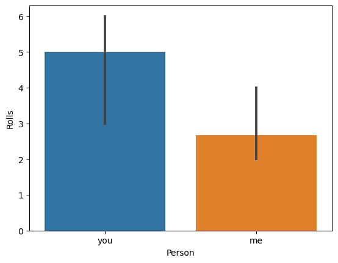

```python
sns.barplot(x="Person", y="Rolls", data=diceRolls)
```

The confidence intervals overlap. This means that we can not yet be sure that you're a better dice roller than me. If we want the confidence intervals to become smaller, we'll need more data which means we need to do more dice rolls.

Let's look if there are significant difference between iris species.

```python
iris.head()
```

|  | sepal_length | sepal_width | petal_length | petal_width | species |
| --- | --- | --- | --- | --- | --- |
| 0 | 5.1 | 3.5 | 1.4 | 0.2 | setosa |
| 1 | 4.9 | 3.0 | 1.4 | 0.2 | setosa |
| 2 | 4.7 | 3.2 | 1.3 | 0.2 | setosa |
| 3 | 4.6 | 3.1 | 1.5 | 0.2 | setosa |
| 4 | 5.0 | 3.6 | 1.4 | 0.2 | setosa |

```python
iris.groupby('species').mean()
```

| species | sepal_length | sepal_width | petal_length | petal_width |
| --- | --- | --- | --- | --- |
| setosa | 5.006 | 3.428 | 1.462 | 0.246 |
| versicolor | 5.936 | 2.770 | 4.260 | 1.326 |
| virginica | 6.588 | 2.974 | 5.552 | 2.026 |

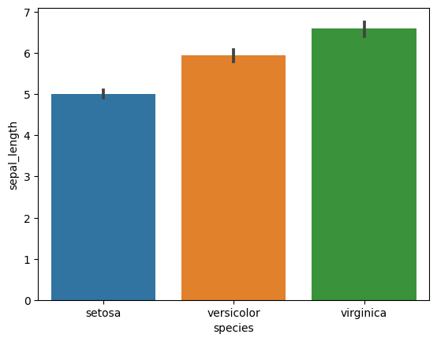

```python
sns.barplot(y="sepal_length", x="species", data=iris)
# Add parameter ci if you want to change certainty of confidence interval.
# For example ci = 99 for 99% certainty.
# The default is 95%
```

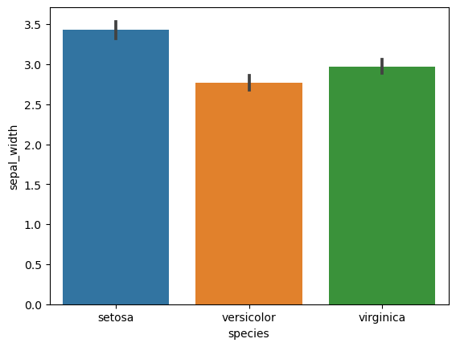

```python
sns.barplot(y="sepal_width", x="species", data=iris)
```

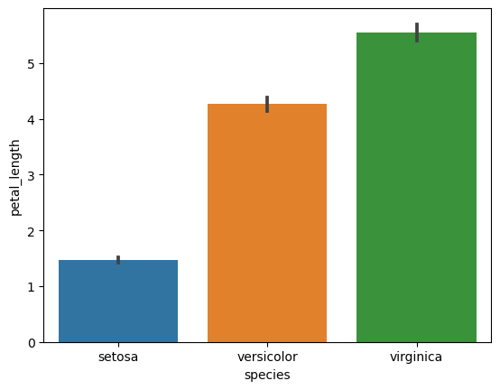

```python
sns.barplot(y="petal_length", x="species", data=iris)
```

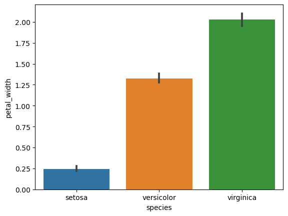

```python
sns.barplot(y="petal_width", x="species", data=iris)
```

### Portfolio assignment 11

20 min: Do a Numerical VS Categorical bivariate analysis on the penguins dataset.

- Choose one of the categorical columns: species, island or sex
- use .groupby('').mean() too look at the means of the numerical columns. Does it look like there is a difference between categories?
- Use the seaborn barplot to plot the mean and confidence. Create this plot for each of the numerical columns (bill_length_mm bill_depth_mm, flipper_length_mm, body_mass_g)
- For each of the plots, write a conclusion: Is there a statistically significant difference for this numerical column for each category?
- Optional: Repeat this proces for the other two categorical columns

```python
penguins.head()
```

|  | species | island | bill_length_mm | bill_depth_mm | flipper_length_mm | body_mass_g | sex |
| --- | --- | --- | --- | --- | --- | --- | --- |
| 0 | Adelie | Torgersen | 39.1 | 18.7 | 181.0 | 3750.0 | Male |
| 1 | Adelie | Torgersen | 39.5 | 17.4 | 186.0 | 3800.0 | Female |
| 2 | Adelie | Torgersen | 40.3 | 18.0 | 195.0 | 3250.0 | Female |
| 3 | Adelie | Torgersen | NaN | NaN | NaN | NaN | NaN |
| 4 | Adelie | Torgersen | 36.7 | 19.3 | 193.0 | 3450.0 | Female |

```python
penguins.groupby(by="species").mean()
```

| species | bill_length_mm | bill_depth_mm | flipper_length_mm | body_mass_g |
| --- | --- | --- | --- | --- |
| Adelie | 38.791391 | 18.346358 | 189.953642 | 3700.662252 |
| Chinstrap | 48.833824 | 18.420588 | 195.823529 | 3733.088235 |
| Gentoo | 47.504878 | 14.982114 | 217.186992 | 5076.016260 |

# Bill length vs Species

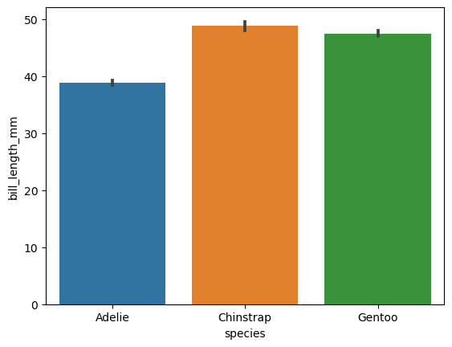

```python
sns.barplot(y="bill_length_mm", x="species", data=penguins)
```

# Bill depth vs Species

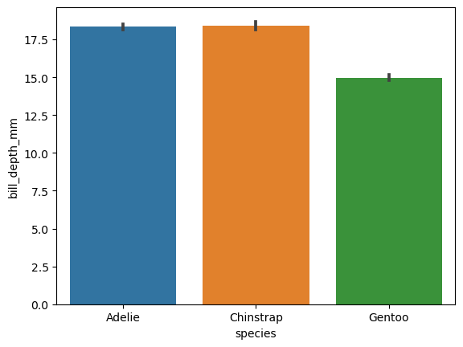

```python
sns.barplot(y="bill_depth_mm", x="species", data=penguins)
```

# Flipper length vs Species

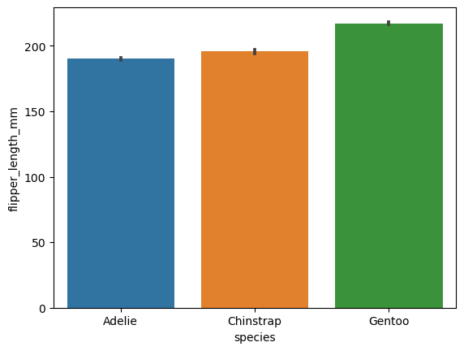

```python
sns.barplot(y="flipper_length_mm", x="species", data=penguins)
```

# Body mass vs Species

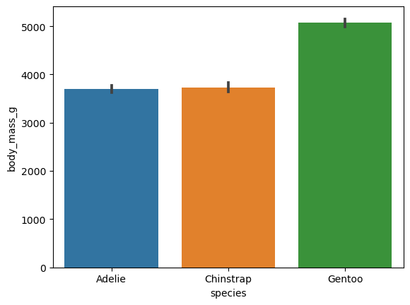

```python
sns.barplot(y="body_mass_g", x="species", data=penguins)
```

[figure not shown]

### Portfolio assignment 12

30 min: Perform a bivariate analysis on at least 3 combinations of a numerical column with a categorical column in the dataset that you chose in portfolio assignment 4. Use *.groupby('columnname').mean()* to calculate the means. Is there a difference between categories? Then use seaborn barplots to check if there is a statistically significant difference.

[figure not shown]